# Global Zooscan transparency

This script explores variation in communities transparency across oceans, day/night and biomes.

Author

Virginie Sonnet

Published

July 9, 2026

```r
source("../config.R")

# general
library(tidyverse)
library(lubridate)
library(ggridges)

library(patchwork)
library(pals)
library(ggridges)
library(stringr)
#library(purr)
library(tidyr)
library(car)
library(broom)
```

# Data

```r
# samples
sp <- read_csv(file.path(cfg$project$data,"imagery_zooscan_samples+acquisitions_cleaned.csv"))

# marine regions and daytime
mr <- read_csv(file.path(cfg$project$data,"imagery_zooscan_samples_marine_regions+daytime.csv")) %>%
  # one summer Arctic sample is missing a day value
  mutate(day_night=if_else(sampleid==378000027,"Day",day_night))

# objects
obj <- read_csv(file.path(cfg$project$data,"imagery_zooscan_objects_morpho_taxo_cleaned.csv")) %>%
  select(objid,sampleid,acquisid,grey_median,grey_std,
         scientificname:family_order) %>%
  left_join(distinct(sp,sampleid,genid,acquisid,d,date,latitude,longitude)) %>%
  left_join(distinct(mr,genid,ocean_seas,longhurstabb,longhurst,day_night,biome))
```

Let’s calculate the average median organism transparency per sample:

```r
sp_mean <- obj %>%
  group_by(genid,date,latitude,longitude,ocean_seas,longhurstabb,longhurst,day_night,biome) %>%
  summarize(gmedian=sum(grey_median*d)/sum(d))
```

# Latitudinal pattern

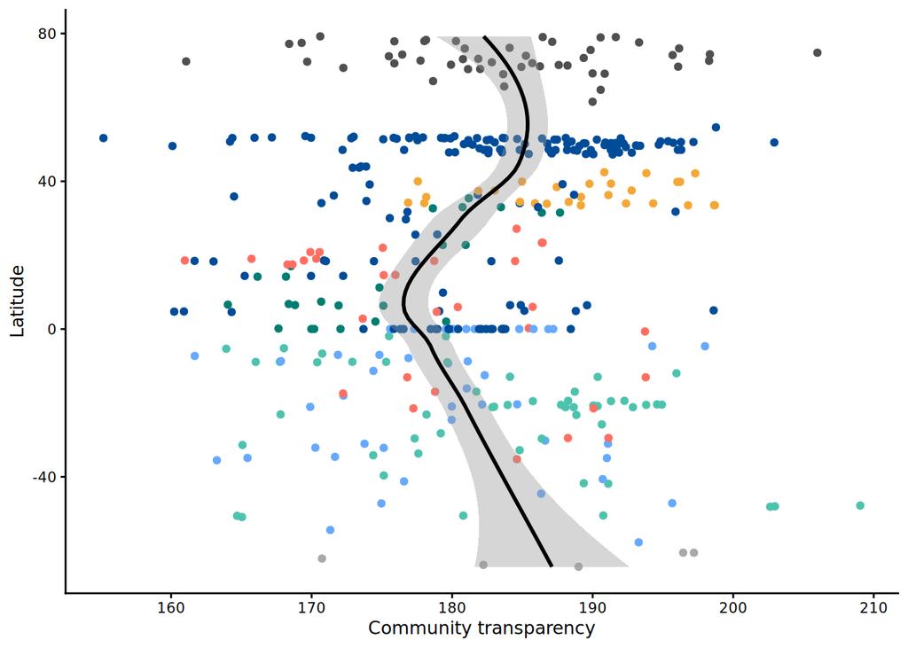

```r
lat <- sp_mean %>%
   mutate(ocean_seas=str_remove(ocean_seas, "\\s+\\w+$")) %>%
  ggplot(aes(x = latitude, y = gmedian)) +
  geom_point(aes(color=ocean_seas)) +
  #eom_point(color="grey30") +
  #geom_point(aes(color=longitude),alpha = 0.6) +
  geom_smooth(method = "loess", color = "black", se = TRUE) +
  theme_classic() +
  coord_flip() +
  scale_color_manual(
    values = c(
      "North Atlantic" = "#004C99",
      "South Atlantic" = "#66A9FF",
      "North Pacific" = "#007D71",
      "South Pacific" = "#4DC3AD",
      "Arctic" = "#505050",
      "Southern" = "#A9A9A9",
      "Indian" = "#FF6F61",
      "Mediterranean" = "#F4A736"
    )) +
  #scale_color_gradientn(colors=kovesi.cyclic_wrwbw_40_90_c42_s25(100)) +
  theme(text = element_text(size = 10),
        legend.position="none") +
  labs(y = "Community transparency", x = "Latitude",color="")
lat
```

# Ocean basins

## Statistics

### Hypothesis

For the average transparency per sample (not the distribution of transparency at the organism level), all oceans have a normal distribution of samples, except for the Northern Atlantic (but W close to 1 and p-value of 0.02 so minor deviation).

We also fail to reject the null hypothesis of equal variance so we can assume that they are indeed homogeneous.

```r
# normality: Shapiro-Wilk test
for (i in unique(sp_mean$ocean_seas)){
  print(i)
  print(shapiro.test(sp_mean$gmedian[sp_mean$ocean_seas==i]))
}
```

```
[1] "North Atlantic Ocean"

    Shapiro-Wilk normality test

data:  sp_mean$gmedian[sp_mean$ocean_seas == i]
W = 0.98147, p-value = 0.02873

[1] "South Pacific Ocean"

    Shapiro-Wilk normality test

data:  sp_mean$gmedian[sp_mean$ocean_seas == i]
W = 0.96892, p-value = 0.1812

[1] "South Atlantic Ocean"

    Shapiro-Wilk normality test

data:  sp_mean$gmedian[sp_mean$ocean_seas == i]
W = 0.98825, p-value = 0.9239

[1] "Mediterranean Region"

    Shapiro-Wilk normality test

data:  sp_mean$gmedian[sp_mean$ocean_seas == i]
W = 0.95017, p-value = 0.2001

[1] "Southern Ocean"

    Shapiro-Wilk normality test

data:  sp_mean$gmedian[sp_mean$ocean_seas == i]
W = 0.9123, p-value = 0.4816

[1] "Indian Ocean"

    Shapiro-Wilk normality test

data:  sp_mean$gmedian[sp_mean$ocean_seas == i]
W = 0.97131, p-value = 0.5557

[1] "North Pacific Ocean"

    Shapiro-Wilk normality test

data:  sp_mean$gmedian[sp_mean$ocean_seas == i]
W = 0.94524, p-value = 0.2132

[1] "Arctic Ocean"

    Shapiro-Wilk normality test

data:  sp_mean$gmedian[sp_mean$ocean_seas == i]
W = 0.99352, p-value = 0.9953
```

```r
# variance
leveneTest(gmedian ~ ocean_seas, data = sp_mean)
```

```
Levene's Test for Homogeneity of Variance (center = median)
       Df F value Pr(>F)
group   7   1.494 0.1678
      388
```

```r
#bartlett.test(gmedian ~ ocean_seas, data = sp_mean)
```

### Tests

Since normality and homogeneity of variance: there are significant differences in the mean between the different oceans/seas.

```r
# one-way ANOVA
anova_result <- aov(gmedian ~ ocean_seas, data = sp_mean)
summary(anova_result)
```

```
             Df Sum Sq Mean Sq F value   Pr(>F)
ocean_seas    7   3618   516.8   6.465 3.22e-07 ***
Residuals   388  31016    79.9
---
Signif. codes:  0 '***' 0.001 '**' 0.01 '*' 0.05 '.' 0.1 ' ' 1
```

```r
# kruskal.test(gmedian ~ ocean_seas, data = sp_mean)

# pairwise test: Tukey
tukey_result <- TukeyHSD(anova_result)
print(tukey_result)
```

```
  Tukey multiple comparisons of means
    95% family-wise confidence level

Fit: aov(formula = gmedian ~ ocean_seas, data = sp_mean)

$ocean_seas
                                                 diff         lwr       upr
Indian Ocean-Arctic Ocean                  -5.1387049 -11.4170221  1.139612
Mediterranean Region-Arctic Ocean           5.1061986  -1.3732543 11.585651
North Atlantic Ocean-Arctic Ocean          -1.8019672  -6.2797466  2.675812
North Pacific Ocean-Arctic Ocean           -9.3526345 -16.1645803 -2.540689
South Atlantic Ocean-Arctic Ocean          -4.1164830  -9.7703524  1.537386
South Pacific Ocean-Arctic Ocean           -0.8575183  -6.2866866  4.571650
Southern Ocean-Arctic Ocean                 3.2282870  -9.5762385 16.032813
Mediterranean Region-Indian Ocean          10.2449035   3.1409957 17.348811
North Atlantic Ocean-Indian Ocean           3.3367377  -2.0048636  8.678339
North Pacific Ocean-Indian Ocean           -4.2139296 -11.6223574  3.194498
South Atlantic Ocean-Indian Ocean           1.0222219  -5.3376866  7.382130
South Pacific Ocean-Indian Ocean            4.2811866  -1.8798251 10.442198
Southern Ocean-Indian Ocean                 8.3669919  -4.7645758 21.498560
North Atlantic Ocean-Mediterranean Region  -6.9081658 -12.4847909 -1.331541
North Pacific Ocean-Mediterranean Region  -14.4588331 -22.0384667 -6.879200
South Atlantic Ocean-Mediterranean Region  -9.2226816 -15.7812240 -2.664139
South Pacific Ocean-Mediterranean Region   -5.9637169 -12.3295718  0.402138
Southern Ocean-Mediterranean Region        -1.8779116 -15.1068236 11.351000
North Pacific Ocean-North Atlantic Ocean   -7.5506673 -13.5103690 -1.590966
South Atlantic Ocean-North Atlantic Ocean  -2.3145158  -6.9059946  2.276963
South Pacific Ocean-North Atlantic Ocean    0.9444489  -3.3673149  5.256213
Southern Ocean-North Atlantic Ocean         5.0302542  -7.3419449 17.402453
South Atlantic Ocean-North Pacific Ocean    5.2361515  -1.6510667 12.123370
South Pacific Ocean-North Pacific Ocean     8.4951162   1.7911320 15.199100
Southern Ocean-North Pacific Ocean         12.5809215  -0.8139808 25.975824
South Pacific Ocean-South Atlantic Ocean    3.2589647  -2.2643529  8.782282
Southern Ocean-South Atlantic Ocean         7.3447700  -5.4999582 20.189498
Southern Ocean-South Pacific Ocean          4.0858053  -8.6616129 16.833224
                                              p adj
Indian Ocean-Arctic Ocean                 0.2008865
Mediterranean Region-Arctic Ocean         0.2434303
North Atlantic Ocean-Arctic Ocean         0.9237427
North Pacific Ocean-Arctic Ocean          0.0009195
```

[output cut: 9 more lines]

```
North Atlantic Ocean-Mediterranean Region 0.0045396
North Pacific Ocean-Mediterranean Region  0.0000004
South Atlantic Ocean-Mediterranean Region 0.0006037
South Pacific Ocean-Mediterranean Region  0.0849287
Southern Ocean-Mediterranean Region       0.9998700
North Pacific Ocean-North Atlantic Ocean  0.0032919
South Atlantic Ocean-North Atlantic Ocean 0.7873505
South Pacific Ocean-North Atlantic Ocean  0.9977551
Southern Ocean-North Atlantic Ocean       0.9197415
South Atlantic Ocean-North Pacific Ocean  0.2869767
South Pacific Ocean-North Pacific Ocean   0.0032835
Southern Ocean-North Pacific Ocean        0.0833063
South Pacific Ocean-South Atlantic Ocean  0.6217245
Southern Ocean-South Atlantic Ocean       0.6591940
Southern Ocean-South Pacific Ocean        0.9774771
```

```r
tukey_tidy <- tidy(tukey_result) %>%
  mutate(p.adj.signif = case_when(
    adj.p.value < 0.001 ~ "***",
    adj.p.value < 0.01 ~ "**",
    adj.p.value < 0.05 ~ "*",
    TRUE ~ "ns"
  )) %>%
  arrange(adj.p.value) %>%
  select(-c(term,null.value)) %>%
  mutate(term1=str_split_i(contrast,"-",1),
         term2=str_split_i(contrast,"-",2))
tukey_tidy
```

```
# A tibble: 28 × 8
   contrast     estimate conf.low conf.high adj.p.value p.adj.signif term1 term2
   <chr>           <dbl>    <dbl>     <dbl>       <dbl> <chr>        <chr> <chr>
 1 North Pacif…   -14.5   -22.0      -6.88  0.000000356 ***          Nort… Medi…
 2 Mediterrane…    10.2     3.14     17.3   0.000379    ***          Medi… Indi…
 3 South Atlan…    -9.22  -15.8      -2.66  0.000604    ***          Sout… Medi…
 4 North Pacif…    -9.35  -16.2      -2.54  0.000919    ***          Nort… Arct…
 5 South Pacif…     8.50    1.79     15.2   0.00328     **           Sout… Nort…
 6 North Pacif…    -7.55  -13.5      -1.59  0.00329     **           Nort… Nort…
 7 North Atlan…    -6.91  -12.5      -1.33  0.00454     **           Nort… Medi…
 8 Southern Oc…    12.6    -0.814    26.0   0.0833      ns           Sout… Nort…
 9 South Pacif…    -5.96  -12.3       0.402 0.0849      ns           Sout… Medi…
10 Indian Ocea…    -5.14  -11.4       1.14  0.201       ns           Indi… Arct…
# ℹ 18 more rows
```

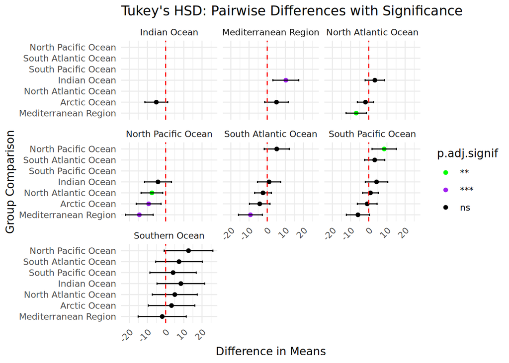

```r
library(ggplot2)

# Plot the differences and confidence intervals
ggplot(tukey_tidy, aes(x = reorder(term2,estimate), y = estimate)) +
  geom_point(aes(color = p.adj.signif)) +
  geom_errorbar(aes(ymin = conf.low, ymax = conf.high), width = 0.2) +
  geom_hline(yintercept = 0, linetype = "dashed", color = "red") +
  facet_wrap(.~term1) +
  scale_color_manual(values = c("ns" = "black", "*" = "blue", "**" = "green", "***" = "purple")) +
  labs(
    x = "Group Comparison",
    y = "Difference in Means",
    title = "Tukey's HSD: Pairwise Differences with Significance"
  ) +
  coord_flip() +
  theme_minimal() +
  theme(axis.text.x = element_text(angle = 45, hjust = 1))
```

## Plot

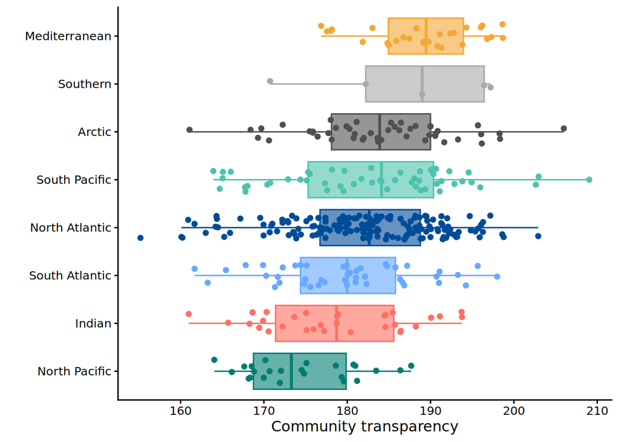

```r
# get the order of mean community transparency per ocean basins
tot_mean <- sp_mean %>%
  group_by(ocean_seas) %>%
  summarize(gmedian=mean(gmedian)) %>%
  arrange(gmedian) %>%
  mutate(ocean_seas=str_remove(ocean_seas, "\\s+\\w+$"))

# boxplot
box_oceans <- sp_mean %>%
  mutate(ocean_seas = str_remove(ocean_seas, "\\s+\\w+$")) %>%
  mutate(ocean_seas = factor(ocean_seas, levels = unique(tot_mean$ocean_seas))) %>%
  ggplot() +
  geom_boxplot(aes(y=gmedian, x= ocean_seas ,colour=ocean_seas, fill = ocean_seas), alpha=0.6, outlier.alpha=0)+
  geom_jitter(aes(y=gmedian, x=ocean_seas ,colour=ocean_seas),width=0.25)+
  coord_flip() +
  scale_color_manual(
    values = c(
      "North Atlantic" = "#004C99",
      "South Atlantic" = "#66A9FF",
      "North Pacific" = "#007D71",
      "South Pacific" = "#4DC3AD",
      "Arctic" = "#505050",
      "Southern" = "#A9A9A9",
      "Indian" = "#FF6F61",
      "Mediterranean" = "#F4A736"
    )) +
  scale_fill_manual(
    values = c(
      "North Atlantic" = "#004C99",
      "South Atlantic" = "#66A9FF",
      "North Pacific" = "#007D71",
      "South Pacific" = "#4DC3AD",
      "Arctic" = "#505050",
      "Southern" = "#A9A9A9",
      "Indian" = "#FF6F61",
      "Mediterranean" = "#F4A736"
    )) +
  labs(x = "", y = "Community transparency", fill = "", color ="")+
  theme_classic(base_size = 12) +
  theme(legend.position="none")
box_oceans
```

```r
sp_mean %>% group_by(ocean_seas) %>% summarize(moy=mean(gmedian),
                                               std=sd(gmedian)) %>% arrange(moy)
```

```
# A tibble: 8 × 3
  ocean_seas             moy   std
  <chr>                <dbl> <dbl>
1 North Pacific Ocean   175.  6.68
2 Indian Ocean          179.  8.65
3 South Atlantic Ocean  180.  8.55
4 North Atlantic Ocean  182.  9.04
5 South Pacific Ocean   183. 10.7
6 Arctic Ocean          184.  8.95
7 Southern Ocean        187. 11.0
8 Mediterranean Region  189.  6.56
```

```r
 # distribution per ocean
ocean_indiv_mean <- obj %>% group_by(ocean_seas) %>%
  summarize(moy=sum(grey_median*d)/sum(d),
            std = sqrt(sum(d * (grey_median - moy)^2) / sum(d))) %>% arrange(moy) %>%
  mutate(ocean_seas = str_remove(ocean_seas, "\\s+\\w+$")) %>%
  mutate(ocean_seas = factor(ocean_seas, levels = unique(tot_mean$ocean_seas)))
ocean_indiv_mean
```

```
# A tibble: 8 × 3
  ocean_seas       moy   std
  <fct>          <dbl> <dbl>
1 North Pacific   170.  29.3
2 Indian          175.  30.6
3 South Atlantic  180.  29.7
4 North Atlantic  180.  29.7
5 Arctic          181.  25.7
6 Mediterranean   185.  25.2
7 South Pacific   185.  29.8
8 Southern        196.  21.1
```

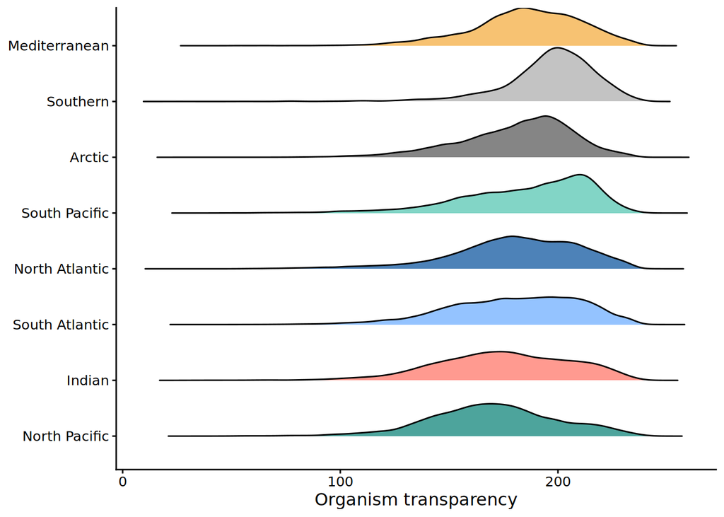

```r
densities <- obj %>%
  mutate(ocean_seas = str_remove(ocean_seas, "\\s+\\w+$")) %>%
  mutate(ocean_seas = factor(ocean_seas, levels = unique(tot_mean$ocean_seas))) %>%
  group_by(ocean_seas) %>%
  summarise(density_data = list({
    subset_data <- grey_median
    subset_weights <- d
    subset_weights <- subset_weights / sum(subset_weights, na.rm = TRUE)

    # Compute weighted mean and sd
    wmean <- sum(subset_data * subset_weights)
    wvar <- sum(subset_weights * (subset_data - wmean)^2)
    wsd <- sqrt(wvar)

    # Use this to estimate bandwidth (rule-of-thumb style)
    bw <- 1.06 * wsd * length(subset_data)^(-1/5)

    dens <- density(subset_data, weights = subset_weights, bw = bw, n = 512)
    tibble(x = dens$x, y = dens$y)
  }), .groups = "drop") %>%
  unnest(density_data)


dist_oceans <- ggplot(densities, aes(x = x, y = ocean_seas, height = y, fill = ocean_seas)) +
  geom_ridgeline(scale = 40, alpha = 0.7) +  # scale to amplify vertical height
  scale_fill_manual(values = c(
    "North Atlantic" = "#004C99",
    "South Atlantic" = "#66A9FF",
    "North Pacific" = "#007D71",
    "South Pacific" = "#4DC3AD",
    "Arctic" = "#505050",
    "Southern" = "#A9A9A9",
    "Indian" = "#FF6F61",
    "Mediterranean" = "#F4A736"
  )) +
  theme_classic() +
  labs(x = "Organism transparency", y = NULL) +
  theme(legend.position = "none", text = element_text(size = 12))
dist_oceans
```

# Day night

## Statistics

### Hypothesis

The day samples are not normally distributed (p=0.005) and there isn’t homogeneity of variance.

```r
# normality: Shapiro-Wilk test
for (i in unique(sp_mean$day_night)){
  print(i)
  print(shapiro.test(sp_mean$gmedian[sp_mean$day_night==i]))
}
```

```
[1] "Day"

    Shapiro-Wilk normality test

data:  sp_mean$gmedian[sp_mean$day_night == i]
W = 0.9862, p-value = 0.005347

[1] "Night"

    Shapiro-Wilk normality test

data:  sp_mean$gmedian[sp_mean$day_night == i]
W = 0.99059, p-value = 0.7551
```

```r
# variance
leveneTest(gmedian ~ day_night, data = sp_mean)
```

```
Levene's Test for Homogeneity of Variance (center = median)
       Df F value   Pr(>F)
group   1  7.0687 0.008164 **
      394
---
Signif. codes:  0 '***' 0.001 '**' 0.01 '*' 0.05 '.' 0.1 ' ' 1
```

```r
#bartlett.test(gmedian ~ ocean_seas, data = sp_mean)
```

### Tests

```r
wilcox.test(gmedian ~ day_night, data = sp_mean, alternative = "two.sided")
```

```
    Wilcoxon rank sum test with continuity correction

data:  gmedian by day_night
W = 18815, p-value = 9.897e-07
alternative hypothesis: true location shift is not equal to 0
```

What about day/night per ocean?

```r
# how many samples
count(ungroup(sp_mean),day_night,ocean_seas) %>% arrange(ocean_seas,n)
```

```
# A tibble: 14 × 3
   day_night ocean_seas               n
   <chr>     <chr>                <int>
 1 Day       Arctic Ocean            48
 2 Night     Indian Ocean            11
 3 Day       Indian Ocean            20
 4 Night     Mediterranean Region     5
 5 Day       Mediterranean Region    23
 6 Night     North Atlantic Ocean    40
 7 Day       North Atlantic Ocean   122
 8 Night     North Pacific Ocean      9
 9 Day       North Pacific Ocean     15
10 Night     South Atlantic Ocean    15
11 Day       South Atlantic Ocean    30
12 Night     South Pacific Ocean     13
13 Day       South Pacific Ocean     40
14 Day       Southern Ocean           5
```

```r
# day night differences
daynight_diff <- sp_mean %>%
  group_by(ocean_seas,day_night) %>%
  summarize(moy=mean(gmedian)) %>%
  pivot_wider(names_from="day_night",values_from="moy") %>%
  mutate(difference=Day-Night)

# two-way ANOVA
mod <- aov(gmedian ~ day_night * ocean_seas,
  data = sp_mean)

# print results
summary(mod)
```

```
                      Df Sum Sq Mean Sq F value   Pr(>F)
day_night              1   1763  1762.6  22.706 2.69e-06 ***
ocean_seas             7   2943   420.4   5.416 6.15e-06 ***
day_night:ocean_seas   5    275    54.9   0.707    0.618
Residuals            382  29654    77.6
---
Signif. codes:  0 '***' 0.001 '**' 0.01 '*' 0.05 '.' 0.1 ' ' 1
```

```r
# linear model
model <- lm(
  gmedian ~ ocean_seas * day_night,
  data = sp_mean
)
summary(model)
```

```
Call:
lm(formula = gmedian ~ ocean_seas * day_night, data = sp_mean)

Residuals:
     Min       1Q   Median       3Q      Max
-27.7595  -5.5952   0.4979   5.8933  24.1639

Coefficients: (2 not defined because of singularities)
                                              Estimate Std. Error t value
(Intercept)                                   183.8932     1.2717 144.603
ocean_seasIndian Ocean                         -3.2594     2.3449  -1.390
ocean_seasMediterranean Region                  5.0528     2.2344   2.261
ocean_seasNorth Atlantic Ocean                 -0.9493     1.5012  -0.632
ocean_seasNorth Pacific Ocean                  -8.9458     2.6062  -3.432
ocean_seasSouth Atlantic Ocean                 -2.4745     2.0506  -1.207
ocean_seasSouth Pacific Ocean                   0.9864     1.8863   0.523
ocean_seasSouthern Ocean                        3.2283     4.1404   0.780
day_nightNight                                 -7.5175     2.8128  -2.673
ocean_seasIndian Ocean:day_nightNight           2.2212     4.3417   0.512
ocean_seasMediterranean Region:day_nightNight   7.8163     5.1781   1.509
ocean_seasNorth Atlantic Ocean:day_nightNight   4.0640     3.2387   1.255
ocean_seasNorth Pacific Ocean:day_nightNight    6.4327     4.6597   1.381
ocean_seasSouth Atlantic Ocean:day_nightNight   2.5917     3.9592   0.655
ocean_seasSouth Pacific Ocean:day_nightNight        NA         NA      NA
ocean_seasSouthern Ocean:day_nightNight             NA         NA      NA
                                              Pr(>|t|)
(Intercept)                                    < 2e-16 ***
ocean_seasIndian Ocean                        0.165350
ocean_seasMediterranean Region                0.024295 *
ocean_seasNorth Atlantic Ocean                0.527545
ocean_seasNorth Pacific Ocean                 0.000664 ***
ocean_seasSouth Atlantic Ocean                0.228273
ocean_seasSouth Pacific Ocean                 0.601317
ocean_seasSouthern Ocean                      0.436048
day_nightNight                                0.007850 **
ocean_seasIndian Ocean:day_nightNight         0.609233
ocean_seasMediterranean Region:day_nightNight 0.132002
ocean_seasNorth Atlantic Ocean:day_nightNight 0.210303
ocean_seasNorth Pacific Ocean:day_nightNight  0.168239
ocean_seasSouth Atlantic Ocean:day_nightNight 0.513110
ocean_seasSouth Pacific Ocean:day_nightNight        NA
ocean_seasSouthern Ocean:day_nightNight             NA
---
Signif. codes:  0 '***' 0.001 '**' 0.01 '*' 0.05 '.' 0.1 ' ' 1

Residual standard error: 8.811 on 382 degrees of freedom
Multiple R-squared:  0.1438,    Adjusted R-squared:  0.1147
F-statistic: 4.935 on 13 and 382 DF,  p-value: 4.957e-08
```

```r
# adjusted
library(emmeans)
emmeans(
  model,
  pairwise ~ day_night | ocean_seas,
  adjust = "BH"
)
```

```
$emmeans
ocean_seas = Arctic Ocean:
 day_night emmean    SE  df lower.CL upper.CL
 Day          184 1.270 382      181      186
 Night     nonEst    NA  NA       NA       NA

ocean_seas = Indian Ocean:
 day_night emmean    SE  df lower.CL upper.CL
 Day          181 1.970 382      177      185
 Night        175 2.660 382      170      181

ocean_seas = Mediterranean Region:
 day_night emmean    SE  df lower.CL upper.CL
 Day          189 1.840 382      185      193
 Night        189 3.940 382      181      197

ocean_seas = North Atlantic Ocean:
 day_night emmean    SE  df lower.CL upper.CL
 Day          183 0.798 382      181      185
 Night        179 1.390 382      177      182

ocean_seas = North Pacific Ocean:
 day_night emmean    SE  df lower.CL upper.CL
 Day          175 2.270 382      170      179
 Night        174 2.940 382      168      180

ocean_seas = South Atlantic Ocean:
 day_night emmean    SE  df lower.CL upper.CL
 Day          181 1.610 382      178      185
 Night        176 2.270 382      172      181

ocean_seas = South Pacific Ocean:
 day_night emmean    SE  df lower.CL upper.CL
 Day          185 1.390 382      182      188
 Night        177 2.440 382      173      182

ocean_seas = Southern Ocean:
 day_night emmean    SE  df lower.CL upper.CL
 Day          187 3.940 382      179      195
 Night     nonEst    NA  NA       NA       NA
```

[output cut: 20 more lines]

```
ocean_seas = North Pacific Ocean:
 contrast    estimate   SE  df t.ratio p.value
 Day - Night    1.085 3.71 382   0.292  0.7704

ocean_seas = South Atlantic Ocean:
 contrast    estimate   SE  df t.ratio p.value
 Day - Night    4.926 2.79 382   1.768  0.0779

ocean_seas = South Pacific Ocean:
 contrast    estimate   SE  df t.ratio p.value
 Day - Night    7.518 2.81 382   2.673  0.0078

ocean_seas = Southern Ocean:
 contrast    estimate   SE  df t.ratio p.value
 Day - Night   nonEst   NA  NA      NA      NA
```

## Plot

```r
# day night
sp_mean %>% group_by(day_night) %>% summarize(moy=mean(gmedian))
```

```
# A tibble: 2 × 2
  day_night   moy
  <chr>     <dbl>
1 Day        183.
2 Night      178.
```

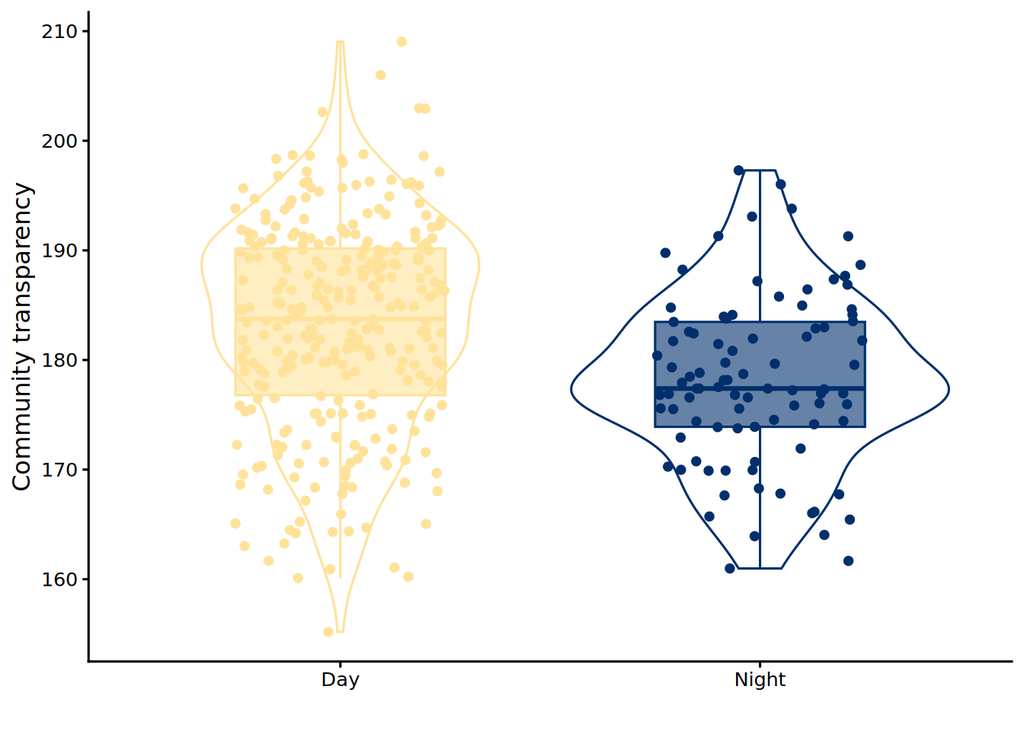

```r
#day night
daynight <- sp_mean %>%
  ggplot() +
  geom_violin(aes(y=gmedian, x= day_night ,colour=day_night), alpha=0.6)+
  geom_boxplot(aes(y=gmedian, x= day_night ,colour=day_night, fill = day_night),width=0.5,alpha=0.6, outlier.alpha=0)+
  geom_jitter(aes(y=gmedian, x=day_night ,colour=day_night),width=0.25)+
  scale_color_manual(
    values = c(
      "Day" = "#FFE29A",
      "Night" = "#002F6C"
    )) +
  scale_fill_manual(
    values = c(
      "Day" = "#FFE29A",
      "Night" = "#002F6C"
    )) +
  labs(x = "", y = "Community transparency", fill = "", color ="")+
  theme_classic(base_size = 12) +
  theme(legend.position="none")
daynight
```

# Biomes

## Statistics

### Hypothesis

The coastal and westerlies biomes are not normal and there isn’t homogeneity of variance.

```r
# normality: Shapiro-Wilk test
for (i in unique(sp_mean$biome)){
  print(i)
  print(shapiro.test(sp_mean$gmedian[sp_mean$biome==i]))
}
```

```
[1] "Westerlies"

    Shapiro-Wilk normality test

data:  sp_mean$gmedian[sp_mean$biome == i]
W = 0.96705, p-value = 0.001532

[1] "Coastal"

    Shapiro-Wilk normality test

data:  sp_mean$gmedian[sp_mean$biome == i]
W = 0.96633, p-value = 0.02421

[1] "Trades"

    Shapiro-Wilk normality test

data:  sp_mean$gmedian[sp_mean$biome == i]
W = 0.9832, p-value = 0.1729

[1] "Polar"

    Shapiro-Wilk normality test

data:  sp_mean$gmedian[sp_mean$biome == i]
W = 0.99129, p-value = 0.9626
```

```r
# variance
leveneTest(gmedian ~ biome, data = sp_mean)
```

```
Levene's Test for Homogeneity of Variance (center = median)
       Df F value  Pr(>F)
group   3  3.4327 0.01711 *
      392
---
Signif. codes:  0 '***' 0.001 '**' 0.01 '*' 0.05 '.' 0.1 ' ' 1
```

```r
#bartlett.test(gmedian ~ ocean_seas, data = sp_mean)
```

### Tests

Do a a Kruskal-Wallis (does not assume normality), and Games-Howell for post-hoc comparisons (robust to unequal variances).

```r
# Kruskal-Wallis
kruskal.test(gmedian ~ biome, data = sp_mean)
```

```
    Kruskal-Wallis rank sum test

data:  gmedian by biome
Kruskal-Wallis chi-squared = 40.189, df = 3, p-value = 9.714e-09
```

```r
# Games-Howell
library(rstatix)
games_howell_test(data = ungroup(sp_mean) %>% mutate(biome=factor(biome)), formula = gmedian ~ biome) %>% arrange(p.adj)
```

```
# A tibble: 6 × 8
  .y.     group1  group2     estimate conf.low conf.high      p.adj p.adj.signif
  <chr>   <chr>   <chr>         <dbl>    <dbl>     <dbl>      <dbl> <chr>
1 gmedian Coastal Westerlies    7.03     3.46   10.6     0.00000566 ****
2 gmedian Trades  Westerlies    4.11     1.49    6.74    0.000391   ***
3 gmedian Coastal Polar         6.65     2.22   11.1     0.000854   ***
4 gmedian Polar   Trades       -3.73    -7.46   -0.00144 0.0499     *
5 gmedian Coastal Trades        2.91    -0.629   6.46    0.146      ns
6 gmedian Polar   Westerlies    0.382   -3.37    4.14    0.993      ns
```

```r
pairwise.wilcox.test(sp_mean$gmedian, sp_mean$biome, p.adjust.method = "BH")
```

```
    Pairwise comparisons using Wilcoxon rank sum test with continuity correction

data:  sp_mean$gmedian and sp_mean$biome

           Coastal Polar   Trades
Polar      0.00021 -       -
Trades     0.01062 0.01062 -
Westerlies 4.5e-07 0.61521 6.1e-05

P value adjustment method: BH
```

## Plot

```r
sp_mean %>% group_by(biome) %>% summarize(moy=mean(gmedian))
```

```
# A tibble: 4 × 2
  biome        moy
  <chr>      <dbl>
1 Coastal     178.
2 Polar       184.
3 Trades      181.
4 Westerlies  185.
```

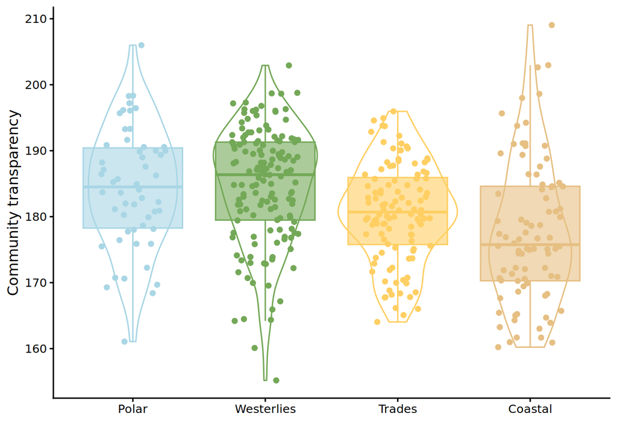

```r
biomes <- sp_mean %>%
  mutate(biome=factor(biome,levels=c("Polar","Westerlies","Trades","Coastal"))) %>%
  ggplot() +
  geom_violin(aes(y=gmedian, x= biome ,colour=biome), alpha=0.6)+
  geom_boxplot(aes(y=gmedian, x= biome ,colour=biome, fill = biome), alpha=0.6, outlier.alpha=0)+
  geom_jitter(aes(y=gmedian, x=biome ,colour=biome),width=0.25)+
  scale_color_manual(
    values = c(
      "Coastal" = "#E6BF83",
      "Polar" = "#A9D6E5",
      "Trades" = "#FFCF63",
      "Westerlies" = "#73A857"
    )) +
  scale_fill_manual(
    values = c(
      "Coastal" = "#E6BF83",
      "Polar" = "#A9D6E5",
      "Trades" = "#FFCF63",
      "Westerlies" = "#73A857"
    )) +
  labs(x = "", y = "Community transparency", fill = "", color ="")+
  theme_classic(base_size = 12) +
  theme(legend.position="none")
biomes
```

# General plot

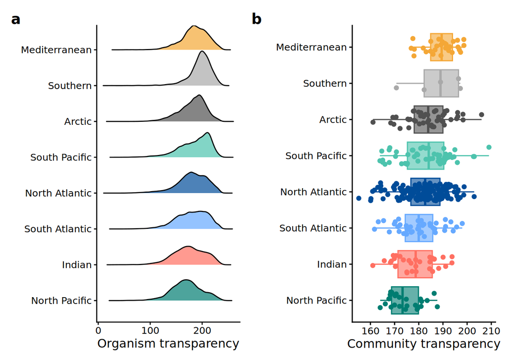

```r
ptop <- (dist_oceans | box_oceans) +
  plot_annotation(tag_levels = list(c("a","b"))) &  # manual tag list
  theme(plot.tag = element_text(face = "bold"),
        plot.tag.position = "topleft")
ptop
```

```r
#ggsave("../figures/Fig5top.tiff",dpi=300,width=7,height=3,scale=1.5)
```

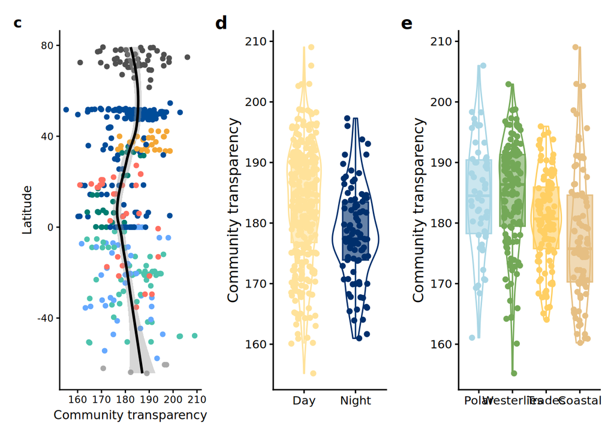

```r
pbottom <- (lat | daynight | biomes) +
  plot_layout(widths=c(1.25,1,1.25)) +
  plot_annotation(tag_levels = list(c("c","d","e"))) &  # manual tag list
  theme(plot.tag = element_text(face = "bold"),
        plot.tag.position = "topleft")
pbottom
```

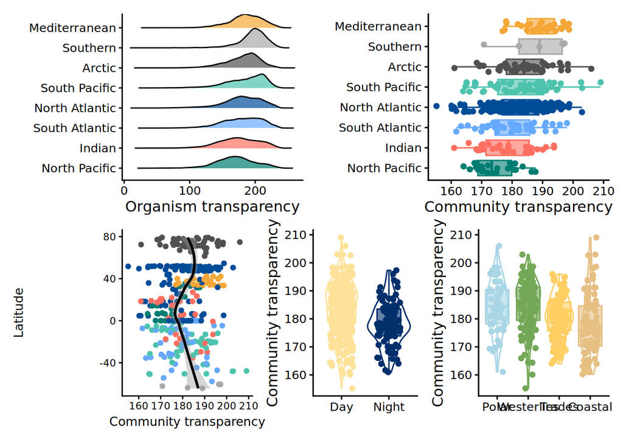

```r
pall <- ptop / pbottom + plot_layout(nrow=2)
pall
```

```r
#ggsave("../figures/Fig5bottom.tiff",dpi=300,width=7,height=3,scale=1.5)
ggsave(file.path(cfg$project$figures,"Fig5_lat_biomes_day_oceans.tiff"),dpi=300,width=7,height=6,scale=1.5)
```